# Simulation exercise in **Genomik und Bioinformatik**

## Part D) Programming - Differential gene expression analysis

**1. Determine the distribution of p-values based on t-tests:**

```r
> library(affy)
> load(file= "C:/Users/aleX/Kurse/genomik/Blatt9/mmml_vsn.rda")
>
> myData <- exprs(mmml.vsn)
> myPheno <- pData(mmml.vsn)
>
> abc_index <- which(myPheno$GCBABC == "ABC")
> gcb_index <- which(myPheno$GCBABC == "GCB")
>
> myList = list(t_score=c(), p_value=c())
>
> for (i in 1:dim(myData)[1]) {
+   abc_samples <- myData[i,abc_index]
+   gcb_samples <- myData[i,gcb_index]
+   result <- t.test(abc_samples, gcb_samples) #TWO-SIDED-TEST
+   myList$t_score[i] <- result$statistic
+   myList$p_value[i] <- result$p.value
+ }
>
> #contains all the p-value for every gene (for gcb & abc comparison)
> str(myList$p_value)
```

```
##  num [1:22283] 0.903679 0.000317 0.067283 0.150873 0.79742 ...
```

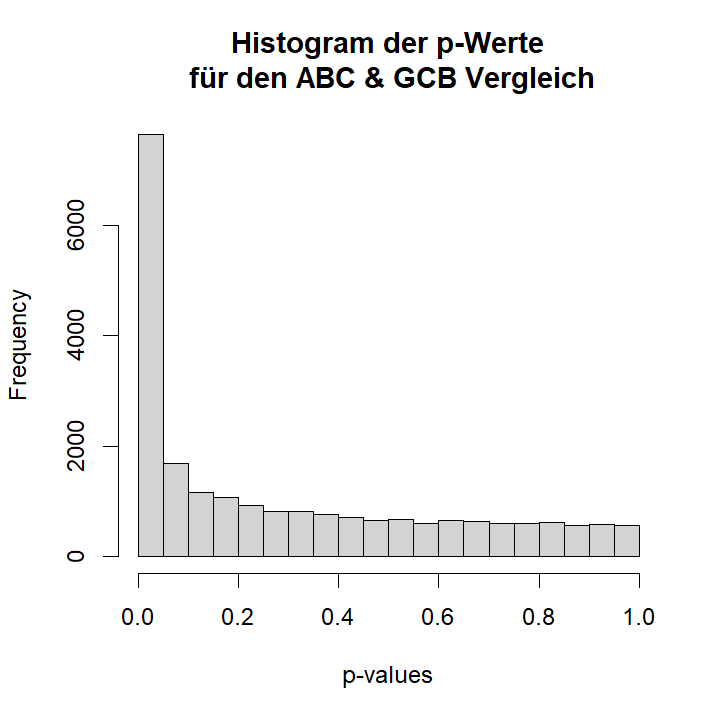

```r
> #histogram
> hist(myList$p_value, xlab="p-values", main="Histogram der p-Werte\n für den ABC & GCB Vergleich")
```

```r
> p_value_below <- which(myList$p_value < 0.05)
> print(paste("Anzahl an Genen unter p=0.05:",length(p_value_below)))
```

```
## [1] "Anzahl an Genen unter p=0.05: 7649"
```

**Answer (1b) & (1c):**  
In a random p-value distribution the p-values would be distributed uniformly (without a big peak)  
In our data we have 7649 genes with p-value below 0.05. In a random distribution we would expect 0.05* *number of genes* = 0.05* 22283 =1114.15. This number is much smaller than our genes with p-value smaller than 0.05 because we have not applied the Bonferroni-correction yet.

**2. Correct p-values for multiple testing:**

```r
> p_value_below_corrected <- which(myList$p_value < 0.05/dim(myData)[1])
> print(paste("Anzahl an Genen unter dem mit Bon. korrigierten p-Werten:", length(p_value_below_corrected)))
```

```
## [1] "Anzahl an Genen unter dem mit Bon. korrigierten p-Werten: 1115"
```

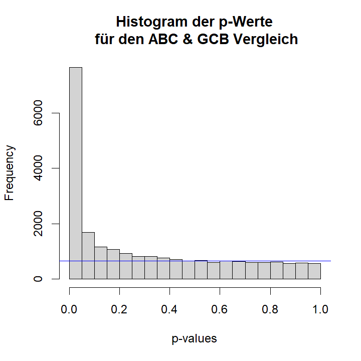

```r
> rueck_hist <- hist(myList$p_value, xlab="p-values", main="Histogram der p-Werte\n für den ABC & GCB Vergleich")
> myMedian <- median(rueck_hist$counts)
> abline(h=myMedian, col="blue")
```

```r
> #false discovery rate
> fdr <- myMedian/rueck_hist$counts[1]
> print(paste("False discovery rate:", round(100*fdr,3), "prozent"))
```

```
## [1] "False discovery rate: 8.596 prozent"
```

**Answer (2):**  
For the Bonferroni-corrected method the standard p-value has to be divided by the number of comparisons in our test. Here we compare the average ABC-value with the average GCB-value for every gene, so the corrected p-value is: 0.05/ *number of genes* = 2.243863^{-6}. With the corrected p-value we have now only 1115 genes below the cutoff. With the Bonferroni-corrected cutoff we would only expect 0.05/ *number of genes* * *number of genes* = 0.05 below the cutoff. That means that only in 5% of our 22283 comparisons we get one gene at all. So the fact that we have 1115 genes below the cutoff means that there are a lot of significant genes.  
The `median()` is more robust to outliers. For our determination of the horizontal cutoff, we want to more or less ignore the left side of the p-value cutoff. Therefore we choose `median()` to draw the false discovery cutoff. As we can see that the horizontal cutoff fits the right side of the p-value cutoff nicely.

**3. Compare lists of differentially expressed genes:**

```
## [1] "number of genes without bon. correction below p-value: 7649"
## [1] "number of genes with bon. correction below p-value: 1115"
```

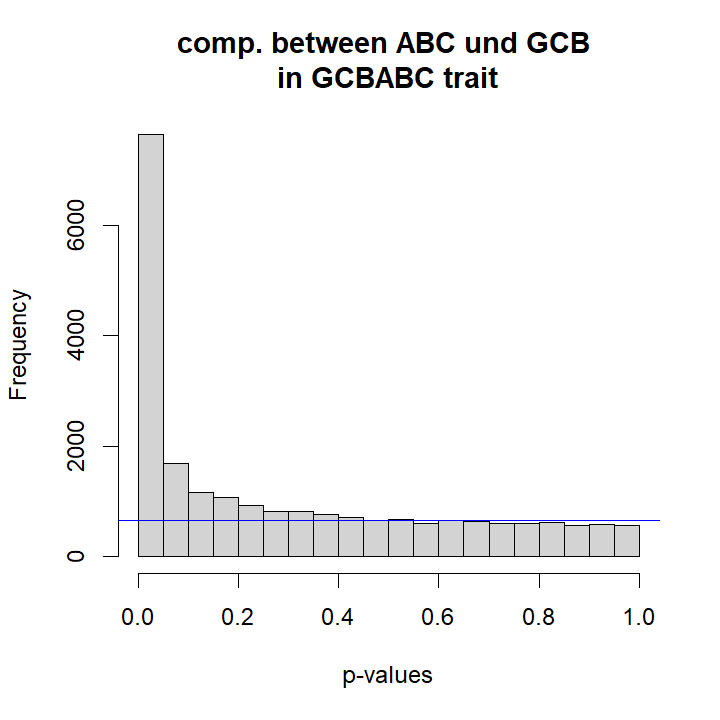

```
## [1] "false discovery rate: 8.596 prozent"
```

```r
> p_func <- function(data, pheno_like, pheno1, pheno2) {
+   myData <- exprs(data)
+   myPheno <- pData(data)
+
+   #GCBABC (ABC & GCB)
+   #MOLDIAG (mBL & non-mBL)
+   abc_index <- which(myPheno[,pheno_like] == pheno1)
+   gcb_index <- which(myPheno[,pheno_like] == pheno2)
+
+   myList = list(t_score=c(), p_value=c())
+
+   for (i in 1:dim(myData)[1]) {
+     abc_samples <- myData[i,abc_index]
+     gcb_samples <- myData[i,gcb_index]
+     result <- t.test(abc_samples, gcb_samples)
+     myList$t_score[i] <- result$statistic
+     myList$p_value[i] <- result$p.value
+   }
+
+   p_value_below <- which(myList$p_value < 0.05)
+   print(paste("number of genes without bon. correction below p-value:", length(p_value_below)))
+
+   p_value_below_corr <- which(myList$p_value < 0.05/dim(myData)[1])
+   print(paste("number of genes with bon. correction below p-value:", length(p_value_below_corr)))
+
+
+   rueck_hist <- hist(myList$p_value, xlab="p-values", main=paste("comp. between", pheno1, "und", pheno2, "\nin", pheno_like, "trait"))
+   myMedian <- median(rueck_hist$counts)
+   abline(h=myMedian, col="blue")
+
+   fdr <- myMedian/rueck_hist$counts[1]
+   print(paste("false discovery rate:", round(100*fdr,3), "prozent"))
+
+   rueck_bool <- myList$p_value < 0.05 #mask
+   rueck_names <- row.names(myData)[rueck_bool]
+
+   return(list(rueck_bool, rueck_names))
+
+ }
> load(file= "C:/Users/aleX/Kurse/genomik/Blatt9/mmml_vsn.rda")
>
> gcbabc_genes <- p_func(mmml.vsn, "GCBABC", "ABC", "GCB")
```

```r
> burkit_genes <- p_func(mmml.vsn, "MOLDIAG", "mBL", "non-mBL")
```

```
## [1] "number of genes without bon. correction below p-value: 14479"
## [1] "number of genes with bon. correction below p-value: 5746"
```

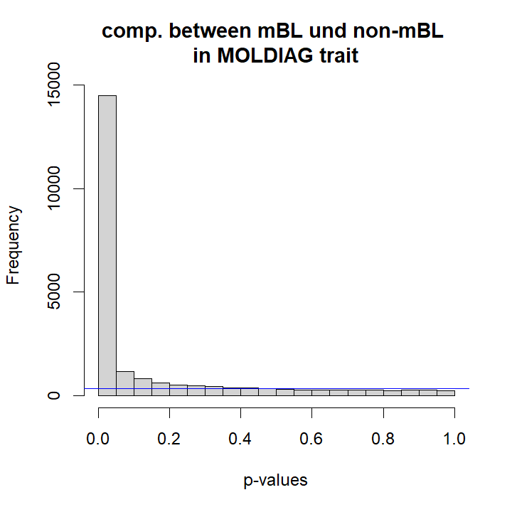

```
## [1] "false discovery rate: 2.296 prozent"
```

```r
> contingency_table <- table(gcbabc_genes[[1]], burkit_genes[[1]])
> contingency_table
```

```
##
##         FALSE TRUE
##   FALSE  5913 8721
##   TRUE   1891 5758
```

```r
> sign_genes_in_both <- intersect(gcbabc_genes[[2]], burkit_genes[[2]])
> length(sign_genes_in_both) #same as contingency_table[[4]] above
```

```
## [1] 5758
```